# Homework 1

Justin Curley

1/12/2020

# Source Script File

```r
source("304736038_stats102a_hw1.R")
```

# gcd

## gcd FlowChart

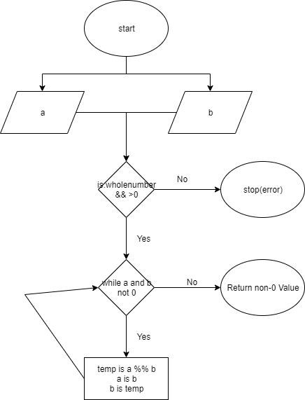

```r
knitr::include_graphics(path="gcd.png")
```

## gcd pseudocode

Check if inputs are valid i.e. a whole number and positive  
Loop while a and b are not 0  
Switch a and b if necessary during initial setup  
Create a temp value for the modulo of a and b  
Set a to old b and b to the temp value  
Once either a or b is 0, return the non 0 value

## gcd Tests Pass

```r
gcd(1071, 462)  # 21
```

```
## [1] 21
```

```r
gcd(462, 1071) # 21
```

```
## [1] 21
```

```r
gcd(646, 1406) # 38
```

```
## [1] 38
```

```r
gcd(1, 10) # 1
```

```
## [1] 1
```

# gcd Tests Fail

```r
try(gcd(0, 12)) # ERROR since 0 is not a positive. THIS SHOULD NOT BE A WARNING BUT AN ERROR. An error means the execution is stopped, while a warning means there is an issue nevertheless  continue with the execution to the end and state what the issue was.
```

```
## Error in gcd(0, 12) :
##   Your input is invalid. Please input two positive integers to find the GCD
```

```r
try(gcd(4.5, 12)) # ERROR
```

```
## Error in gcd(4.5, 12) :
##   Your input is invalid. Please input two positive integers to find the GCD
```

```r
try(gcd(-1, 12)) # ERROR
```

```
## Error in gcd(-1, 12) :
##   Your input is invalid. Please input two positive integers to find the GCD
```

# gcd_3

## gcd_3 FlowChart

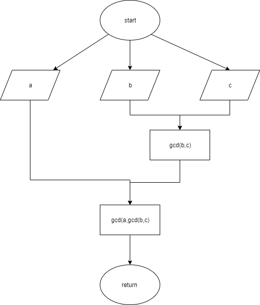

```r
knitr::include_graphics(path="gcd_3.png")
```

## gcd_3 Pseudocode

Compute the gcd of b and c  
Compute the gcd of a and the result of gcd of b and c

## gcd_3 Tests Pass

```r
gcd_3(1071, 462, 4452)
```

```
## [1] 21
```

```r
gcd_3(646,1406, 4218)
```

```
## [1] 38
```